# Final Modeling Notebook Intro

Authors: Tim Gorman, Yu Cao, Ling Zhou

In this notebook we take the data output from data_prep2.0 (`"./foursquare-location-matchin/cao_code/data_prep2.0.ipynb"`) </br> This data has some important aspects: </br>

- Curated Ground Truth Data
  - This is the raw data from kaggle after removing nans, noise and reducing to only data with country_1 and country_2 both being 'US'.
  - Label:
    - match - Indicates whether two ids represent the same point of interest
  - Features:
    - id_1, id_2
    - Modeling Features:
    - name_1, name_2
    - latitude_1, latitude_2
    - longitude_1, longitude_2
    - address_1, address_2
    - city_1, city_2
    - state_1, state_2
    - country_1, country_2
    - url_1, url_2
    - phone_1, phone_2
    - categories_1, categories_2
- Differenced Data
  - Lat./Long. Differences
    - Simply Euclidean Differences (geo_diff)
    - Angular Difference (geo_theta_diff)
  - String differences
    - Three different ways to calucate differences
      - Sequence Matching (*_seq)
      - Levenshtein Distance (*_lev)
      - Cosine Similarity (*_csim)

We then take the different ways to difference data and run them through a Logistic regression model to see which differencing method performs best. Based on this, the best method will be sent through a random forest classification model. At the end of the notebook we'll compare all of the results against two naive models.

# Library and Data Imports

```python
#Library Imports
import pandas as pd
import numpy as np
from sklearn.model_selection import (train_test_split, cross_validate,
                                     StratifiedKFold, GridSearchCV, RandomizedSearchCV)
from sklearn.linear_model import LogisticRegression
from sklearn.metrics import (confusion_matrix, roc_auc_score, f1_score,
                             accuracy_score, precision_score, jaccard_score, recall_score,
                             precision_recall_curve, roc_curve)
from sklearn.ensemble import RandomForestClassifier
import seaborn as sns
import matplotlib.pyplot as plt
import random

import itertools

from shapely.geometry import Point
from geopandas import GeoDataFrame
import geopandas as gpd
```

```python
# This data is the curated data that comes out of "data_prep2.0"
data = pd.read_csv(r"..\data_curated\pairs_us_diffs.csv", low_memory = False)
```

```python
# A dictionary that defines which features to use when modeling with different string metrics
# (sequence matching, cosine similarity, levenshtein).
feature_dict = {'x_col_csim': ['geo_theta_diff', 'name_csim', 'address_csim',
       'city_csim', 'state_csim', 'zip_csim', 'url_csim', 'phone_csim',
       'categories_csim'],
                'x_col_seq':['geo_theta_diff', 'name_diff_seq',
       'address_diff_seq', 'city_diff_seq','state_diff_seq', 'zip_diff_seq',
       'url_diff_seq', 'phone_diff_seq', 'categories_diff_seq'],
               'x_col_lev':['geo_theta_diff', 'name_diff_lev',
       'address_diff_lev', 'city_diff_lev','state_diff_lev', 'zip_diff_lev',
       'url_diff_lev', 'phone_diff_lev', 'categories_diff_lev'] }
```

# Function Definitions

```python
# Defining Modeling Functions
def logistic_regression_pipe(features, labels):
    x_train, x_test, y_train, y_test = train_test_split(features, labels,
                                                    shuffle      = True,
                                                    random_state = 614,
                                                    test_size    = 0.2,
                                                    stratify     = labels)
    skf  = StratifiedKFold(n_splits = 10, shuffle = True, random_state = 614)
    lreg = LogisticRegression()
    #HyperParameters
    solvers = ['newton-cg', 'lbfgs', 'liblinear']
    penalty = ['l2']
    c_values = [100, 50, 10, 5, 1.0, 0.5, 0.1, 0.05, 0.01]
    grid = dict(solver=solvers,penalty=penalty,C=c_values)
    grid_search = GridSearchCV(estimator=lreg, param_grid=grid, n_jobs=-1, cv=skf, scoring='accuracy',error_score=0)
    grid_result = grid_search.fit(x_train, y_train)
    # print("Best: %f using %s" % (grid_result.best_score_, grid_result.best_params_))
    print("Best mean test score {:5.5f} using {}".format(grid_result.best_score_, grid_result.best_params_))
    means  = grid_result.cv_results_['mean_test_score']
    stds   = grid_result.cv_results_['std_test_score']
    params = grid_result.cv_results_['params']
    print("mean     std             param")
    print("------------------------------"*2)
    for mean, stdev, param in zip(means, stds, params):
        # print("%f (%f) with: %r" % (mean, stdev, param))
        print("{:5.5f}  ({:5.5f}) with: {}".format(mean, stdev, param))
    return grid_result.best_params_

def random_forest_pipe(features, labels):
    x_train, x_test, y_train, y_test = train_test_split(features, labels,
                                                    shuffle      = True,
                                                    random_state = 614,
                                                    test_size    = 0.2,
                                                    stratify     = data['match'])
    #Defining Estimators
    # Number of trees in random forest
    n_estimators = [int(x) for x in np.linspace(start = 200, stop = 1200, num = 6)]
    # Number of features to consider at every split
    max_features = ['auto', 'sqrt']
    # Maximum number of levels in tree
    max_depth = [int(x) for x in np.linspace(10, 110, num = 11)]
    max_depth.append(None)
    # Minimum number of samples required to split a node
    min_samples_split = [2, 5, 10]
    # Minimum number of samples required at each leaf node
    min_samples_leaf = [2, 4, 10]
    # Method of selecting samples for training each tree
    bootstrap = [True, False]
    # Create the random grid
    random_grid = {'n_estimators'     : n_estimators,
                   'max_features'     : max_features,
                   'max_depth'        : max_depth,
                   'min_samples_split': min_samples_split,
                   'min_samples_leaf' : min_samples_leaf,
                   'bootstrap'        : bootstrap}
    # Use the random grid to search for best hyperparameters
    # First create the base model to tune
    rf = RandomForestClassifier()
    # Random search of parameters, using 3 fold cross validation,
    # search across 100 different combinations, and use all available cores
    rf_random = RandomizedSearchCV(estimator = rf,
                                   param_distributions = random_grid,
                                   n_iter = 10, cv = 3, verbose=2,
                                   random_state=614, n_jobs = -1)
    # Fit the random search model
    rf_random.fit(x_train, y_train)

    print(rf_random.best_params_)

    return rf_random.best_params_
```

# Logistic Regression With Hyperparameter tuning and K-fold Cross_validation

```python
best_params_dict = {}
for features in feature_dict:
    print(40*'-.')
    print(features)
    best_params = logistic_regression_pipe(features = data[feature_dict[features]], labels = data['match'])
    best_params_dict[features] = best_params
```

```
-.-.-.-.-.-.-.-.-.-.-.-.-.-.-.-.-.-.-.-.-.-.-.-.-.-.-.-.-.-.-.-.-.-.-.-.-.-.-.-.
x_col_csim
Best mean test score 0.73952 using {'C': 0.05, 'penalty': 'l2', 'solver': 'newton-cg'}
mean     std             param
------------------------------------------------------------
0.73923  (0.00253) with: {'C': 100, 'penalty': 'l2', 'solver': 'newton-cg'}
0.73922  (0.00252) with: {'C': 100, 'penalty': 'l2', 'solver': 'lbfgs'}
0.73924  (0.00251) with: {'C': 100, 'penalty': 'l2', 'solver': 'liblinear'}
0.73923  (0.00253) with: {'C': 50, 'penalty': 'l2', 'solver': 'newton-cg'}
0.73922  (0.00252) with: {'C': 50, 'penalty': 'l2', 'solver': 'lbfgs'}
0.73924  (0.00251) with: {'C': 50, 'penalty': 'l2', 'solver': 'liblinear'}
0.73924  (0.00255) with: {'C': 10, 'penalty': 'l2', 'solver': 'newton-cg'}
0.73922  (0.00253) with: {'C': 10, 'penalty': 'l2', 'solver': 'lbfgs'}
0.73925  (0.00253) with: {'C': 10, 'penalty': 'l2', 'solver': 'liblinear'}
0.73923  (0.00254) with: {'C': 5, 'penalty': 'l2', 'solver': 'newton-cg'}
0.73920  (0.00252) with: {'C': 5, 'penalty': 'l2', 'solver': 'lbfgs'}
0.73924  (0.00252) with: {'C': 5, 'penalty': 'l2', 'solver': 'liblinear'}
0.73918  (0.00252) with: {'C': 1.0, 'penalty': 'l2', 'solver': 'newton-cg'}
0.73918  (0.00252) with: {'C': 1.0, 'penalty': 'l2', 'solver': 'lbfgs'}
0.73917  (0.00251) with: {'C': 1.0, 'penalty': 'l2', 'solver': 'liblinear'}
0.73919  (0.00251) with: {'C': 0.5, 'penalty': 'l2', 'solver': 'newton-cg'}
0.73920  (0.00251) with: {'C': 0.5, 'penalty': 'l2', 'solver': 'lbfgs'}
0.73922  (0.00252) with: {'C': 0.5, 'penalty': 'l2', 'solver': 'liblinear'}
0.73936  (0.00262) with: {'C': 0.1, 'penalty': 'l2', 'solver': 'newton-cg'}
0.73934  (0.00262) with: {'C': 0.1, 'penalty': 'l2', 'solver': 'lbfgs'}
0.73935  (0.00263) with: {'C': 0.1, 'penalty': 'l2', 'solver': 'liblinear'}
0.73952  (0.00241) with: {'C': 0.05, 'penalty': 'l2', 'solver': 'newton-cg'}
0.73951  (0.00241) with: {'C': 0.05, 'penalty': 'l2', 'solver': 'lbfgs'}
0.73940  (0.00244) with: {'C': 0.05, 'penalty': 'l2', 'solver': 'liblinear'}
0.73895  (0.00221) with: {'C': 0.01, 'penalty': 'l2', 'solver': 'newton-cg'}
0.73893  (0.00221) with: {'C': 0.01, 'penalty': 'l2', 'solver': 'lbfgs'}
0.73893  (0.00223) with: {'C': 0.01, 'penalty': 'l2', 'solver': 'liblinear'}
-.-.-.-.-.-.-.-.-.-.-.-.-.-.-.-.-.-.-.-.-.-.-.-.-.-.-.-.-.-.-.-.-.-.-.-.-.-.-.-.
x_col_seq
Best mean test score 0.75204 using {'C': 0.1, 'penalty': 'l2', 'solver': 'liblinear'}
mean     std             param
------------------------------------------------------------
0.75193  (0.00292) with: {'C': 100, 'penalty': 'l2', 'solver': 'newton-cg'}
0.75192  (0.00292) with: {'C': 100, 'penalty': 'l2', 'solver': 'lbfgs'}
0.75193  (0.00292) with: {'C': 100, 'penalty': 'l2', 'solver': 'liblinear'}
```

[output cut: 41 more lines]

```
0.75854  (0.00278) with: {'C': 1.0, 'penalty': 'l2', 'solver': 'newton-cg'}
0.75855  (0.00275) with: {'C': 1.0, 'penalty': 'l2', 'solver': 'lbfgs'}
0.75858  (0.00280) with: {'C': 1.0, 'penalty': 'l2', 'solver': 'liblinear'}
0.75854  (0.00277) with: {'C': 0.5, 'penalty': 'l2', 'solver': 'newton-cg'}
0.75853  (0.00276) with: {'C': 0.5, 'penalty': 'l2', 'solver': 'lbfgs'}
0.75858  (0.00280) with: {'C': 0.5, 'penalty': 'l2', 'solver': 'liblinear'}
0.75859  (0.00270) with: {'C': 0.1, 'penalty': 'l2', 'solver': 'newton-cg'}
0.75859  (0.00270) with: {'C': 0.1, 'penalty': 'l2', 'solver': 'lbfgs'}
0.75872  (0.00273) with: {'C': 0.1, 'penalty': 'l2', 'solver': 'liblinear'}
0.75878  (0.00266) with: {'C': 0.05, 'penalty': 'l2', 'solver': 'newton-cg'}
0.75878  (0.00266) with: {'C': 0.05, 'penalty': 'l2', 'solver': 'lbfgs'}
0.75901  (0.00263) with: {'C': 0.05, 'penalty': 'l2', 'solver': 'liblinear'}
0.75991  (0.00248) with: {'C': 0.01, 'penalty': 'l2', 'solver': 'newton-cg'}
0.75991  (0.00248) with: {'C': 0.01, 'penalty': 'l2', 'solver': 'lbfgs'}
0.76058  (0.00263) with: {'C': 0.01, 'penalty': 'l2', 'solver': 'liblinear'}
```

```python
best_params_dict['x_col_lev']
```

```
{'C': 0.01, 'penalty': 'l2', 'solver': 'liblinear'}
```

What I get from above is that the levenshtein distance works as the best metric. I ran this twice with "geo_diff" and "geo_theta_diff" (not shown with "geo_diff"). They give nearly identical results so I'll stick with "geo_theta_diff" because I believe it to be the most accurate metric. </br> </br> Here's what I will use for the "best logistic regression" on the test set.

x_col_lev Best: 0.760583 using {'C': 0.01, 'penalty': 'l2', 'solver': 'liblinear'}

```python
skf = StratifiedKFold(n_splits = 10, shuffle = True, random_state = 614)
```

```python
lreg_best = LogisticRegression(penalty = best_params_dict['x_col_lev']['penalty'],
                               solver  = best_params_dict['x_col_lev']['solver'],
                               C       = best_params_dict['x_col_lev']['C'])
```

```python
#Defining Test Set that will be used for next logistic regression
x_train, x_test, y_train, y_test = train_test_split(data[feature_dict['x_col_lev']], data['match'],
                                                    shuffle      = True,
                                                    random_state = 614,
                                                    test_size    = 0.2,
                                                    stratify     = data['match'])
```

```python
scores = cross_validate(lreg_best, x_train, y_train,
                        cv      = skf,
                        scoring = ['accuracy', 'roc_auc', 'f1', 'average_precision', 'jaccard'],
                        n_jobs  = -1)
```

Results

```python
print('Mean Accuracy')
print(np.mean(scores['test_accuracy']))
print('Mean roc_auc')
print(np.mean(scores['test_roc_auc']))
print('Mean F1')
print(np.mean(scores['test_f1']))
print('Mean Average Precision')
print(np.mean(scores['test_average_precision']))
print('Mean Jaccard')
print(np.mean(scores['test_jaccard']))
```

```
Mean Accuracy
0.760582842053666
Mean roc_auc
0.7403987339534928
Mean F1
0.8486189798741022
Mean Average Precision
0.8587794766704114
Mean Jaccard
0.7370479052953229
```

## Logistic Regression on Test Set

```python
lreg_best.fit(x_train, y_train)
lreg_best_y_pred = lreg_best.predict(x_test)
```

```python
confusion_matrix(y_test, lreg_best_y_pred)
```

```
array([[ 2075,  4544],
       [ 1141, 15781]], dtype=int64)
```

```python
roc_auc_score(y_test, lreg_best_y_pred)
```

```
0.623032222942199
```

```python
f1_score(y_test, lreg_best_y_pred)
```

```
0.8473702580073563
```

```python
accuracy_score(y_test, lreg_best_y_pred)
```

```
0.7585064355804766
```

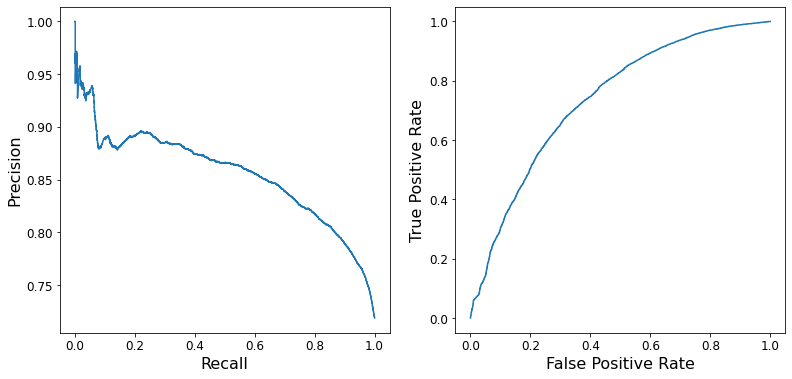

```python
fig, axs = plt.subplots(1,2,figsize=(13,6))
precision, recall, thresholds = precision_recall_curve(y_test, lreg_best.predict_proba(x_test)[:,1])
axs[0].plot(recall,precision)
axs[0].set_xlabel("Recall",fontsize=16)
axs[0].set_ylabel("Precision",fontsize=16)
axs[0].tick_params(axis='both',labelsize=12)

# ax.tick_params(axis='x', Labelsize= )

fpr, tpr, thresholds = roc_curve(y_test, lreg_best.predict_proba(x_test)[:,1])
axs[1].plot(fpr,tpr)
axs[1].set_xlabel("False Positive Rate",fontsize=16)
axs[1].set_ylabel("True Positive Rate",fontsize=16)
axs[1].tick_params(axis='both',labelsize=12)

# plt.tight_layout()

plt.show()
```

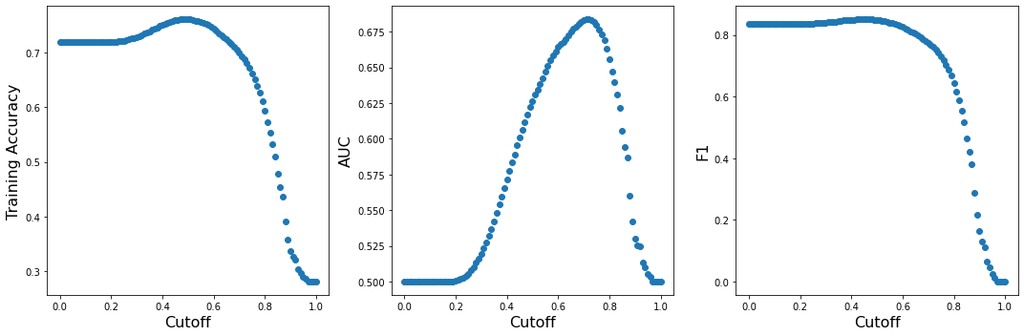

```python
cutoffs = np.arange(0, 1.01, 0.01)
y_train_prob = lreg_best.predict_proba(x_train)[:,1]
accs = []
aucs = []
f1s = []
precision = []
recall = []
for cutoff in cutoffs:
    cutoffs = np.arange(0, 1.01, 0.01)
    y_train_pred = 1*(y_train_prob >= cutoff)

    #accs.append(np.sum(y_train_pred == y_train)/len(y_train))
    accs.append(accuracy_score(y_train, y_train_pred))
    aucs.append(roc_auc_score(y_train, y_train_pred))
    f1s.append(f1_score(y_train, y_train_pred))

fig, axs = plt.subplots(1,3,figsize=(15,5))

axs[0].scatter(cutoffs,accs)
axs[0].set_xlabel("Cutoff",fontsize=16)
axs[0].set_ylabel("Training Accuracy",fontsize=16)

axs[1].scatter(cutoffs,aucs)
axs[1].set_xlabel("Cutoff",fontsize=16)
axs[1].set_ylabel("AUC",fontsize=16)

axs[2].scatter(cutoffs,f1s)
axs[2].set_xlabel("Cutoff",fontsize=16)
axs[2].set_ylabel("F1",fontsize=16)

plt.tight_layout()

plt.show()
```

# Random Forest with Hyperparameter Tuning

Becuase the Levenshtein distance served as the best string difference metric through the logistic regression analysis, we'll use this as the input data set for the following random forest model.

```python
#Train Test Split Using Levensthein Columns
x_train, x_test, y_train, y_test = train_test_split(data[feature_dict['x_col_lev']], data['match'],
                                                    shuffle = True,
                                                    random_state = 614,
                                                    test_size = 0.2,
                                                    stratify = data['match'])
```

## Hyperparameter Tuning

```python
best_params = random_forest_pipe(features = data[feature_dict['x_col_lev']], labels = data['match'])
```

```
Fitting 3 folds for each of 10 candidates, totalling 30 fits
{'n_estimators': 400, 'min_samples_split': 2, 'min_samples_leaf': 4, 'max_features': 'auto', 'max_depth': 20, 'bootstrap': False}
```

## Tuned Random Forest on Test Data

```python
rf_best = RandomForestClassifier(best_params['n_estimators'],
                                 max_features      = best_params['max_features'],
                                 random_state      = 614,
                                 min_samples_split = best_params['min_samples_split'],
                                 min_samples_leaf  = best_params['min_samples_leaf'],
                                 max_depth         = best_params['max_depth'])
```

```python
x_train, x_test, y_train, y_test = train_test_split(data[feature_dict['x_col_lev']], data['match'],
                                                    shuffle      = True,
                                                    random_state = 614,
                                                    test_size    = 0.2,
                                                    stratify     = data['match'])
```

```python
rf_best.fit(x_train,y_train)
```

```
RandomForestClassifier(max_depth=20, min_samples_leaf=4, n_estimators=400,
                       random_state=614)
```

```python
rf_best_y_pred = rf_best.predict(x_test)
```

```python
f1_score(y_test, rf_best_y_pred)
```

```
0.8753860231041976
```

```python
accuracy_score(y_test, rf_best_y_pred)
```

```
0.8148761734845589
```

```python
roc_auc_score(y_test, rf_best_y_pred)
```

```
0.7450745275832473
```

```python
confusion_matrix(y_test, rf_best_y_pred)
```

```
array([[ 3876,  2743],
       [ 1615, 15307]], dtype=int64)
```

```python
rf_best.feature_importances_
```

```
array([0.107883  , 0.30215246, 0.14564726, 0.02213798, 0.00800429,
       0.03250015, 0.03940099, 0.10506787, 0.23720601])
```

# Simple Models

## A Naive Model V1: (developed by Ling Zhou)

```python
baseline_cols = ['geo_diff', 'name_diff_lev', 'address_diff_lev']
```

```python
x_train, x_test, y_train, y_test = train_test_split(data[baseline_cols], data['match'],
                                                    shuffle      = True,
                                                    random_state = 614,
                                                    test_size    = 0.2,
                                                    stratify     = data['match'])
```

```python
def baseline(df, cols, thresh):
    df_copy = df.copy()
    df_copy['match'] = np.random.choice([True, False], len(df))
    df_copy.loc[df_copy[cols].max(axis=1)<thresh] = True

    return df_copy
```

```python
# Using Levenshtein distance
#cols = ['location_diff','name_diff','address_diff']
#y_test = data['match']
naive_1_y_pred = baseline(x_test, baseline_cols, 0.1).match
print(confusion_matrix(y_test, naive_1_y_pred),'\n', roc_auc_score(y_test,naive_1_y_pred))
```

```
[[ 3068  3551]
 [ 5488 11434]]
 0.5696012894512275
```

```python
f1_score(y_test, naive_1_y_pred)
```

```
0.7167079324286207
```

```python
accuracy_score(y_test, naive_1_y_pred)
```

```
0.6160316044348159
```

```python
roc_auc_score(y_test, naive_1_y_pred)
```

```
0.5696012894512275
```

## A Naive Model V2: Guess all matches are True

```python
sample_arr = [True]

naive_2_y_pred = np.random.choice(sample_arr, len(y_test))
```

```python
naive_2_y_pred
```

```
array([ True,  True,  True, ...,  True,  True,  True])
```

```python
confusion_matrix(y_test, naive_2_y_pred)
```

```
array([[    0,  6619],
       [    0, 16922]], dtype=int64)
```

```python
roc_auc_score(y_test, naive_2_y_pred)
```

```
0.5
```

```python
f1_score(y_test, naive_2_y_pred)
```

```
0.8364184563675457
```

```python
accuracy_score(y_test, naive_2_y_pred)
```

```
0.7188309757444459
```

# Comparison of Results

Genearting a data frame that has all of the relevant scores

```python
results_dict = { "metrics":['F1',"Accuracy", 'AUC', 'Jaccard'],
                'Random Forest':[f1_score(y_test, rf_best_y_pred),
                     accuracy_score(y_test, rf_best_y_pred),
                     roc_auc_score(y_test, rf_best_y_pred),
                     jaccard_score(y_test, rf_best_y_pred)],
                "Logistic Regression":[f1_score(y_test, lreg_best_y_pred),
                     accuracy_score(y_test, lreg_best_y_pred),
                     roc_auc_score(y_test, lreg_best_y_pred),
                     jaccard_score(y_test, lreg_best_y_pred)],
                "1st Naive":[f1_score(y_test, naive_1_y_pred),
                     accuracy_score(y_test, naive_1_y_pred),
                     roc_auc_score(y_test, naive_1_y_pred),
                     jaccard_score(y_test, naive_1_y_pred)],
                "2nd Naive":[f1_score(y_test, naive_2_y_pred),
                     accuracy_score(y_test, naive_2_y_pred),
                     roc_auc_score(y_test, naive_2_y_pred),
                     jaccard_score(y_test, naive_2_y_pred)]
               }
```

```python
scores_df = pd.DataFrame(results_dict)
```

```python
scores_df
```

|  | metrics | Random Forest | Logistic Regression | 1st Naive | 2nd Naive |
| --- | --- | --- | --- | --- | --- |
| 0 | F1 | 0.875386 | 0.847370 | 0.716708 | 0.836418 |
| 1 | Accuracy | 0.814876 | 0.758506 | 0.616032 | 0.718831 |
| 2 | AUC | 0.745075 | 0.623032 | 0.569601 | 0.500000 |
| 3 | Jaccard | 0.778388 | 0.735163 | 0.558492 | 0.718831 |

```python
for item in scores_df:
    print(item)
```

```
metrics
Random Forest
Logistic Regression
1st Naive
2nd Naive
```

```python
colors = plt.cm.magma(np.linspace(0, 1, 4))
```

```python
for i, score in enumerate(scores_df):
    print(i)
```

```
0
1
2
3
4
```

```
Random Forest
Logistic Regression
1st Naive
1st Naive
2nd Naive
2nd Naive
```

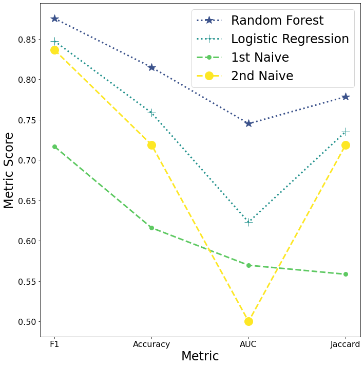

```python
fig, ax = plt.subplots(1,1, figsize=(10,10))
marker = itertools.cycle(('*', '+', '.', 'o'))
linestyle = itertools.cycle((':', ':', '--', '--'))
colors = plt.cm.viridis(np.linspace(0, 1.0, len(scores_df)+1))
for i, score in enumerate(scores_df):
    if score != 'metrics':
        print(score)
        if (score == '1st Naive') | (score == '2nd Naive'):
            print(score)
            linesytle = '--'
        ax.plot(scores_df['metrics'], scores_df[score],
                marker = next(marker),
                markersize = 16,
               label = score,
               linestyle = next(linestyle),
                linewidth = 3,
               color = colors[i])

ax.set_xlabel("Metric",fontsize=24)
ax.set_ylabel("Metric Score",fontsize=24)
plt.xticks(fontsize = 16)
plt.yticks(fontsize = 16)
plt.legend(fontsize = 24)

plt.tight_layout()

plt.show()
```

## Geographic Dependence

```python
geo_cols = ['latitude_1', 'longitude_1']
```

```python
x_train, x_test, y_train, y_test = train_test_split(data[geo_cols], data['match'],
                                                    shuffle      = True,
                                                    random_state = 614,
                                                    test_size    = 0.2,
                                                    stratify     = data['match'])
```

```python
geo_data = x_test
```

```python
geo_data['rf_best_y_pred'] = rf_best_y_pred
```

```python
geo_data['match'] = y_test
```

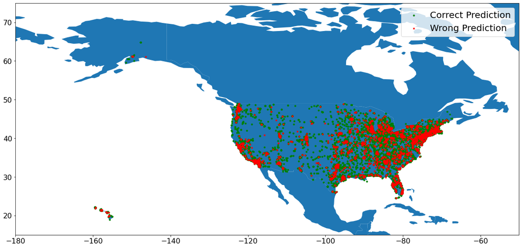

```python
geometry = [Point(xy) for xy in zip(geo_data['longitude_1'][geo_data['rf_best_y_pred']==geo_data['match']], geo_data['latitude_1'][geo_data['rf_best_y_pred']==geo_data['match']])]
gdf = GeoDataFrame(geo_data[geo_data['rf_best_y_pred']==geo_data['match']].copy(), geometry=geometry)

geometry_false = [Point(xy) for xy in zip(geo_data['longitude_1'][geo_data['rf_best_y_pred']!=geo_data['match']], geo_data['latitude_1'][geo_data['rf_best_y_pred']!=geo_data['match']])]
gdf_false = GeoDataFrame(geo_data[geo_data['rf_best_y_pred']!=geo_data['match']].copy(), geometry=geometry_false)
#this is a simple map that goes with geopandas
world = gpd.read_file(gpd.datasets.get_path('naturalearth_lowres'))
fig, ax = plt.subplots(figsize=(20, 12))
world.plot(figsize=(20, 12), ax=ax)
gdf.plot(ax=ax, marker='o', color='green', markersize=10, label = 'Correct Prediction')
gdf_false.plot(ax=ax, marker='x', color='red', markersize=10, label = 'Wrong Prediction')

plt.xlim([-180,-50])
plt.ylim([15,75])
plt.xticks(fontsize = 16)
plt.yticks(fontsize = 16)
plt.legend(fontsize = 20)
plt.show()
```

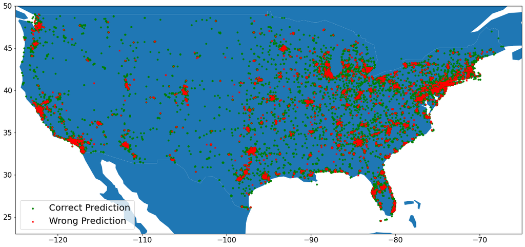

```python
geometry = [Point(xy) for xy in zip(geo_data['longitude_1'][geo_data['rf_best_y_pred']==geo_data['match']], geo_data['latitude_1'][geo_data['rf_best_y_pred']==geo_data['match']])]
gdf = GeoDataFrame(geo_data[geo_data['rf_best_y_pred']==geo_data['match']].copy(), geometry=geometry)

geometry_false = [Point(xy) for xy in zip(geo_data['longitude_1'][geo_data['rf_best_y_pred']!=geo_data['match']], geo_data['latitude_1'][geo_data['rf_best_y_pred']!=geo_data['match']])]
gdf_false = GeoDataFrame(geo_data[geo_data['rf_best_y_pred']!=geo_data['match']].copy(), geometry=geometry_false)
#this is a simple map that goes with geopandas
world = gpd.read_file(gpd.datasets.get_path('naturalearth_lowres'))
fig, ax = plt.subplots(figsize=(20, 12))
world.plot(figsize=(20, 12), ax=ax)
gdf.plot(ax=ax, marker='o', color='green', markersize=10, label = 'Correct Prediction')
gdf_false.plot(ax=ax, marker='x', color='red', markersize=10, label = 'Wrong Prediction')


plt.xlim([-125,-65])
plt.ylim([23,50])
plt.xticks(fontsize = 16)
plt.yticks(fontsize = 16)
plt.legend(fontsize = 20)
plt.show()
```

```python
geo_cols = ['latitude_2', 'longitude_2']
```

```python
x_train, x_test, y_train, y_test = train_test_split(data[geo_cols], data['match'],
                                                    shuffle      = True,
                                                    random_state = 614,
                                                    test_size    = 0.2,
                                                    stratify     = data['match'])
```

```python
geo_data = x_test
```

```python
geo_data['rf_best_y_pred'] = rf_best_y_pred
```

```python
geo_data['match'] = y_test
```

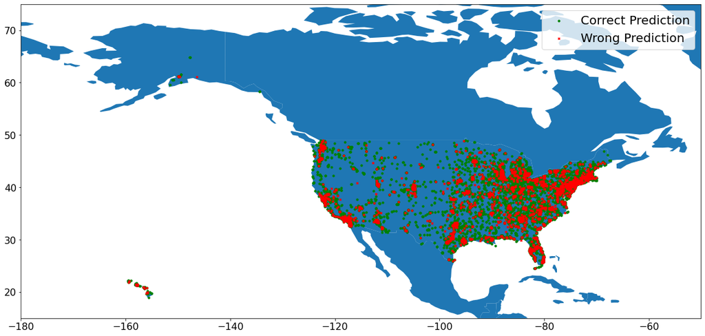

```python
geometry = [Point(xy) for xy in zip(geo_data['longitude_2'][geo_data['rf_best_y_pred']==geo_data['match']], geo_data['latitude_2'][geo_data['rf_best_y_pred']==geo_data['match']])]
gdf = GeoDataFrame(geo_data[geo_data['rf_best_y_pred']==geo_data['match']].copy(), geometry=geometry)

geometry_false = [Point(xy) for xy in zip(geo_data['longitude_2'][geo_data['rf_best_y_pred']!=geo_data['match']], geo_data['latitude_2'][geo_data['rf_best_y_pred']!=geo_data['match']])]
gdf_false = GeoDataFrame(geo_data[geo_data['rf_best_y_pred']!=geo_data['match']].copy(), geometry=geometry_false)
#this is a simple map that goes with geopandas
world = gpd.read_file(gpd.datasets.get_path('naturalearth_lowres'))
fig, ax = plt.subplots(figsize=(20, 12))
world.plot(figsize=(20, 12), ax=ax)
gdf.plot(ax=ax, marker='o', color='green', markersize=10, label = 'Correct Prediction')
gdf_false.plot(ax=ax, marker='x', color='red', markersize=10, label = 'Wrong Prediction')

plt.xlim([-180,-50])
plt.ylim([15,75])
plt.xticks(fontsize = 16)
plt.yticks(fontsize = 16)
plt.legend(fontsize = 20)
plt.show()
```